# Objetos de Mediação na Extensão Rural · Conhecimento Cotidiano, Ciência, Técnica e Tecnologia Social

Extensão Rural

Prof. Dr. Luiz Diego Vidal Santos

## Abertura Visão Geral da Aula

Roteiro da aula Tópicos principais

- 1 Conhecimento Cotidiano e Saber Local
- 2 Ciência e Conhecimento Científico
- 3 Técnica e Tecnologia
- 4 Tecnologia Social
- 5 Mediação e o Papel do Extensionista

Objetivo central Diálogo entre saberes no campo

Compreender os diferentes tipos de conhecimento que circulam na prática extensionista e como o extensionista atua como mediador entre saberes distintos na construção de soluções para o meio rural.

Saber local Ciência agronômica Tecnologia social Mediação

Do saber empírico dos territórios à tradução dialógica e à co-construção de tecnologias sociais.

# Objetos de Mediação e Saberes

## Mediação O que são objetos de mediação?

Conceito central · Coelho (2014) Pontes entre atores do campo

Na extensão rural, os **objetos de mediação** são os elementos que conectam extensionistas, agricultores e pesquisadores em processos de interação e construção de conhecimento (Coelho, 2014).

Natureza e função Superação dos pacotes prontos

Incluem artefatos, práticas, saberes e linguagens que circulam entre os atores. Compreendê-los permite estabelecer diálogos produtivos, evitando a imposição unilateral de pacotes tecnológicos e valorizando múltiplas fontes de saber.

O extensionista não é apenas um transmissor de informações, mas um **facilitador de encontros** entre formas distintas de conhecer e agir sobre a realidade agrária (Freire, 1983).

## Mediação Conhecimento Cotidiano e Saber Local

Toledo e Barrera-Bassols (2009) Memória biocultural e prática

O saber local, também chamado de conhecimento cotidiano ou popular, resulta de gerações de observação, experimentação e adaptação dos agricultores às condições de solo, clima e arranjos produtivos de seus territórios.

Expressões concretas Exemplos no campo

Transmitido oralmente, enraizado na prática e sensível ao contexto ecológico, manifesta-se no manejo de **sementes crioulas**, no uso de **bioindicadores vegetais** de fertilidade do solo e nos **calendários agrícolas** baseados em sinais naturais.

Características do saber local Cinco atributos centrais

1. Transmissão oral e intergeracional
2. Base empírica e adaptativa
3. Contexto-dependente (território)
4. Holístico (integra dimensões produtivas, culturais e espirituais)
5. Frequentemente invisibilizado pela ciência convencional

## Mediação Ciência e Conhecimento Científico

Gomes (2005) Produção científica

Produzido por métodos sistemáticos de observação, formulação de hipóteses, experimentação controlada e revisão por pares — expresso em **resultados de pesquisa** de universidades, Embrapa e instituições internacionais.

Chambers (1997) Limite do modelo linear

A ciência agronômica trouxe avanços em genética, solo, irrigação e fitossanidade. Contudo, o modelo linear (*ciência gera → extensionista transfere → agricultor adota*) mostrou-se **insuficiente** para a complexidade dos sistemas agrários.

Desafio atual Interface dialógica

Estabelecer diálogo horizontal entre conhecimento científico e saber local para que ambos se complementem e se enriqueçam mutuamente em soluções adaptadas ao território.

A ciência oferece precisão analítica e causalidade; o saber local aporta leitura territorial, historicidade e viabilidade adaptativa.

# Técnica, Tecnologia e Tecnologia Social

## Tecnologia Técnica e Tecnologia na Extensão Rural

Dagnino (2004) Técnica

Consiste em procedimentos e habilidades práticas desenvolvidos para resolver problemas específicos: preparo do solo, semeadura, poda, colheita e processamento.

Pode originar-se tanto no **saber local** (roça de toco, coivara) quanto na **pesquisa científica** (plantio direto, irrigação por gotejamento).

Não-neutralidade · Dagnino (2004) Tecnologia

É o conjunto organizado de conhecimentos científicos e técnicos aplicados a um processo produtivo ou social, envolvendo sistematização, padronização e incorporação de capital.

A escolha tecnológica **nunca é neutra**: reflete visões de mundo, relações de poder e modelos de desenvolvimento que incluem ou excluem agricultores.

## Tecnologia Tecnologia Convencional vs. Tecnologia Social

Paradigma 1 Tecnologia Convencional

**1. Origem:** gerada em laboratório e ambiente controlado

**2. Formato:** padronizada para larga escala homogênea

**3. Dependência:** requer insumos externos contínuos

**4. Acesso:** intensiva em capital e crédito

Paradigma 2 Tecnologia Social

**1. Origem:** co-construída com as comunidades

**2. Formato:** adaptável ao contexto socioambiental

**3. Autonomia:** baseada no uso de recursos locais

**4. Acesso:** acessível, de baixo custo e replicável

A tecnologia social nasce do diálogo entre saberes para responder a demandas sociais concretas com **baixo custo e alta replicabilidade** (ITS Brasil, 2004).

## Diagrama Paradigmas Tecnológicos na Extensão Rural

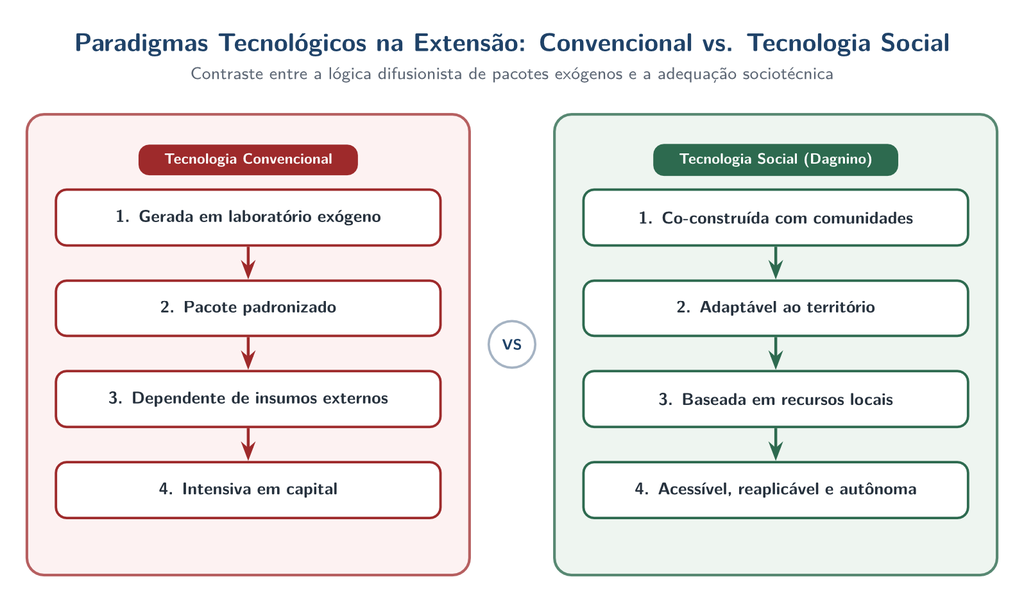

Tecnologia Convencional vs. Tecnologia Social na Extensão Rural Contrastes entre o pacote exógeno padronizado e a co-construção adaptada ao território (Dagnino, 2004; ITS Brasil, 2004)

**Critério agronômico:** tecnologias sociais não recusam ciência — reorientam o conhecimento técnico para autonomia, recursos locais e reprodutibilidade camponesa.

## Tecnologia Tecnologia Social na Prática

ITS Brasil · RTS / FBB (2004) Conceito operacional

“Produtos, técnicas ou metodologias reaplicáveis, desenvolvidas na interação com a comunidade e que representem efetivas soluções de transformação social” (ITS Brasil, 2004).

Exemplos no meio rural brasileiro Escala com enraizamento local

A **cisterna de placas do P1MC** foi implantada em mais de **1,2 milhão** de propriedades no semiárido. Outros exemplos incluem os **biodigestores sertanejos**, as **fossas sépticas biodigestoras da Embrapa** e os **quintais produtivos agroecológicos**.

Critérios de Tecnologia Social (RTS) Cinco requisitos essenciais

1. Responder a uma demanda social concreta
2. Ser desenvolvida em interação com a comunidade
3. Ser reaplicável em diferentes contextos
4. Gerar transformação social efetiva
5. Ter baixo custo e uso de recursos locais

# Mediação e Interface entre Saberes

## Mediação Objetos de Mediação Sociotécnica na Comunicação Rural

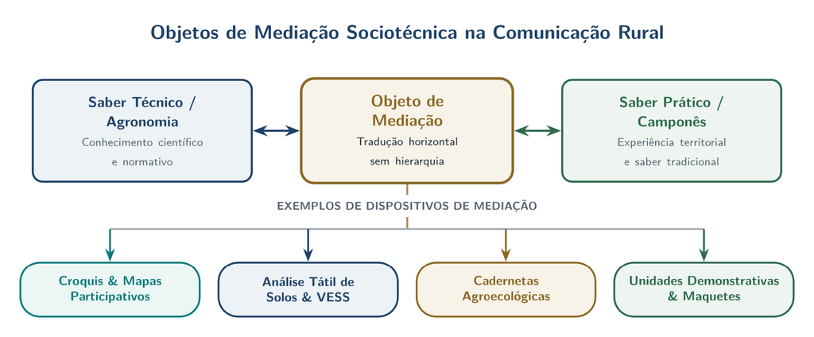

Objetos de mediação sociotécnica articulando saber técnico agronômico e saber prático camponês por meio de croquis, análise tátil VESS, cadernetas agroecológicas e unidades demonstrativas.

Dispositivos de tradução horizontal sem hierarquia entre saberes Croquis e mapas participativos · Análise tátil de solos e VESS · Cadernetas agroecológicas · Unidades demonstrativas e maquetes

Os objetos de mediação materializam o diálogo entre agronomia e prática camponesa em linguagem compartilhada.

## Mediação O Extensionista como Mediador de Saberes

Paulo Freire (1983): *“O conhecimento não se estende do que se julga sabedor até aqueles que se julga não saberem”* — crítica à postura extensionista que ignora os saberes do agricultor.

Prática cotidiana · Coelho (2014) O que faz o mediador?

Envolve escuta ativa, tradução de linguagens técnicas para linguagem acessível, valorização de saberes locais e facilitação de processos coletivos de experimentação e aprendizagem — articulando ciência, técnica e conhecimento cotidiano.

Formação do agrônomo Competências necessárias

Deve incluir comunicação intercultural, reconhecimento de epistemologias diversas e capacidade de dialogar com agricultores, pesquisadores, gestores públicos e organizações da sociedade civil.

## Mediação A Interface Saber Local e Ciência

01 · Polo territorial Saber Local

Agricultores aportam observação empírica, biodiversidade e manejo territorial em **diálogo** contínuo.

02 · Mediação Extensionista

Atua como **mediador** intercultural e facilitador de encontros entre linguagens e práticas.

03 · Polo acadêmico Ciência

Pesquisa agronômica oferece métodos, explicação causal e **tradução** técnica contextualizada.

04 · Resultado cíclico Inovação Co-construída

Solução compartilhada que **retroalimenta** tanto o saber dos agricultores quanto a agenda científica.

Superar o modelo linear (pesquisa → extensão → agricultor) exige arquiteturas interativas em que os saberes se articulam horizontalmente e retroalimentam-se continuamente (Chambers, 1997).

# Desafios, Conclusão e Referências

## Desafios Desafios Contemporâneos da Mediação

Obstáculo epistemológico · Santos (2007) Hierarquização de saberes

O desafio mais profundo reside na hierarquização entre conhecimento científico e saber popular, que frequentemente relega o segundo à condição de “crença” ou “atraso”.

Obstáculo institucional Lacuna na formação agrária

A formação dos profissionais de ciências agrárias ainda privilegia a dimensão técnico-produtiva em detrimento das competências de comunicação, facilitação e leitura de contextos socioculturais.

**1. Epistemologia:** superar a hierarquia entre saberes científicos e locais.

**2. Formação:** preparar extensionistas mediadores, não apenas técnicos executores.

**3. Pluralidade:** reconhecer a diversidade de sistemas de conhecimento no campo.

**4. Sustentabilidade:** integrar inovação tecnológica e transformação social.

**5. Escala:** ampliar tecnologias sociais sem perder a identidade local.

## Síntese Conclusão

Superação do difusionismo Articulação de conhecimentos

A compreensão dos objetos de mediação é requisito fundamental para uma prática profissional que reconheça, valorize e articule saber empírico dos agricultores, produção científica recente, técnicas tradicionais e tecnologias sociais emergentes.

Ciências agrárias Extensão dialógica e inclusiva

Incorporar essa perspectiva na formação agronômica contribui para uma extensão rural mais dialógica, inclusiva e efetiva frente aos desafios complexos do desenvolvimento rural sustentável no Brasil.

## Referências Referências Bibliográficas

Epistemologia e mediação Saberes e comunicação

- CHAMBERS, R. *Whose Reality Counts? Putting the First Last*. London: ITDG, 1997.
- COELHO, F. M. G. *A Arte das Orientações Técnicas no Campo*. Rio Branco: Suprema, 2014.
- FREIRE, P. *Extensão ou Comunicação?* Rio de Janeiro: Paz e Terra, 1983.
- SANTOS, B. S. Para além do pensamento abissal. *Novos Estudos CEBRAP*, n. 79, 2007.

Agroecologia e tecnologia social Fundamentos técnicos

- DAGNINO, R. *Tecnologia Social: ferramenta para construir outra sociedade*. Campinas: Unicamp, 2004.
- GOMES, J. C. C. Bases epistemológicas da agroecologia. In: AQUINO, A. N.; ASSIS, R. L. *Agroecologia: princípios e técnicas*. Brasília: Embrapa, 2005.
- ITS BRASIL. *Tecnologia Social: uma estratégia para o desenvolvimento*. Rio de Janeiro: FBB, 2004.
- TOLEDO, V. M.; BARRERA-BASSOLS, N. *A Memória Biocultural*. São Paulo: Expressão Popular, 2009.